# Poisson Regression

## Introduction

- We have previously discussed continuous outcomes:
  - $y \sim N(\mu, \sigma^2)$
  - $y \sim \text{gamma}(\mu, \gamma)$
  - $y \sim \text{beta}(\alpha, \beta)$
  - $y \sim \text{binomial}(n, \pi)$
  - $y \sim \text{multinomial}(n, [\pi_1, ... \pi_c])$
- This week, we will consider count outcomes:
  - Poisson
  - Negative binomial

## Poisson Regression

- We can model count outcomes using Poisson regression,

$$\ln\left( y \right) = \beta_0 + \beta_1 x_1 + ... + \beta_k x_k$$

- This is similar to gamma regression with $\ln()$.
  - For interpretations, we are not interested in the natural log of the count.
  - We will interpret in terms of incident rate ratios (IRR) instead of multiplicative effects on the mean.

## Poisson Regression

- Poisson regression is used specifically for *count response variables*.
  - Examples:
    - Number of votes received
    - Number of attempts before success
- How is this different than gamma regression?
  - Gamma regression is used for *continuous response variables* that are positive and right-skewed.
    - Support is $(0, \infty)$.
  - Poisson regression is used for *count response variables* that are non-negative integers.
    - Support is $\{0, 1, 2, ..., \infty\}$.

## Poisson Distribution

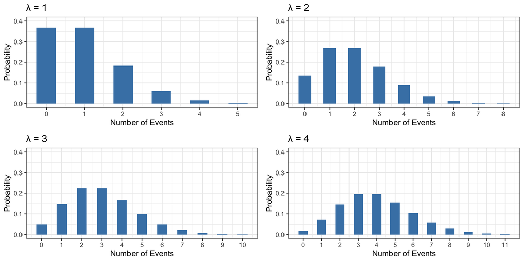

## Poisson Distribution

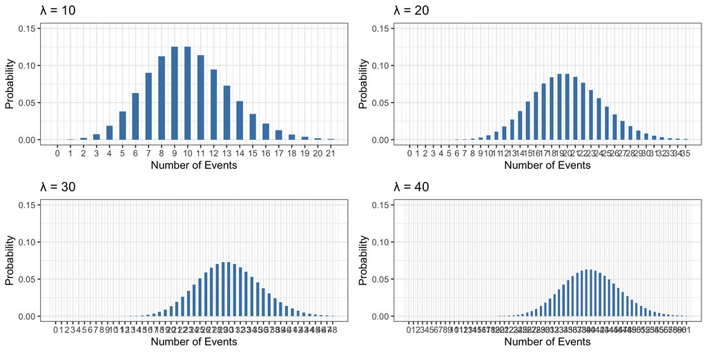

## Lecture Example Set Up

- Pluto spends his days at Mickey’s park chasing squirrels and interacting with guests. Disney researchers are interested in understanding what factors influence the number of squirrels Pluto chases per hour.
- For 300 observation periods, researchers recorded:
  - *squirrels_chased*: Number of squirrels chased during the observation period
  - *temperature*: Temperature (°F)
  - *crowd*: Park crowd level (guests per 100 people)
  - *mickey_present*: Whether Mickey is present (Yes/No)
  - *time_of_day*: Time of day (Morning, Afternoon, Evening)

## Lecture Example Set Up

- Pulling in the data,

```r
pluto <- read_csv("https://raw.githubusercontent.com/samanthaseals/SDSII/refs/heads/main/files/data/lectures/W6_pluto.csv")
pluto %>% head()
```

| squirrels_chased | temperature | crowd | mickey_present | time_of_day |
| --- | --- | --- | --- | --- |
| 66 | 71 | 42.6 | Yes | Afternoon |
| 40 | 71 | 58.2 | No | Afternoon |
| 37 | 84 | 62.1 | No | Morning |
| 54 | 88 | 46.1 | Yes | Morning |
| 48 | 76 | 56.5 | No | Afternoon |
| 57 | 76 | 69.3 | Yes | Evening |

## Lecture Example

- Let’s look at the outcome variable, *squirrels_chased*.

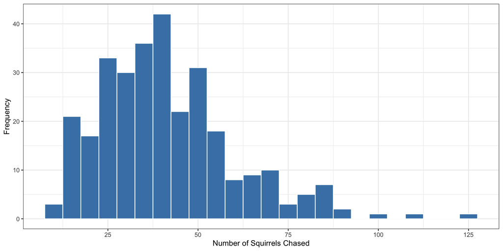

## Poisson Regression (R)

- We are able to again use the `glm()` function when specifying the Poisson distribution.

```r
m <- glm(y ~ x_1 + x_2 + ... + x_k,
         data = dataset_name,
         family = poisson(link = "log"))
```

- Everything we have learned about how to use model results applies here as well.

## Example 1: Poisson Regression

- Let’s model the number of squirrels chased as a function of temperature, crowd, and their interaction.

```r
m1 <- glm(squirrels_chased ~ temperature + crowd + temperature:crowd,
                 data = pluto,
                 family = poisson(link = "log"))
m1 %>% tidy()
```

| term | estimate | std.error | statistic | p.value |
| --- | --- | --- | --- | --- |
| (Intercept) | 0.1857624458 | 3.277795e-01 | 0.5667299 | 5.708977e-01 |
| temperature | 0.0363002481 | 4.313848e-03 | 8.4148190 | 3.935022e-17 |
| crowd | 0.0393306623 | 6.113214e-03 | 6.4337124 | 1.245243e-10 |
| temperature:crowd | -0.0003112087 | 8.055095e-05 | -3.8635017 | 1.117731e-04 |

## Example 1: Poisson Regression

- The resulting regresion model is,

```r
m1 %>% coefficients()
```

```
      (Intercept)       temperature             crowd temperature:crowd
     0.1857624458      0.0363002481      0.0393306623     -0.0003112087
```

$$\ln(\hat{y}) = 0.19 + 0.04 \text{ temp} + 0.04 \text{ crowd} - 0.0003 \text{ temp} \times \text{crowd}$$

## Interpreting the Model

- Recall the Poisson regression model,

$$\ln\left( y \right) = \beta_0 + \beta_1 x_1 + ... + \beta_k x_k$$

## Incident Rate Ratios (R)

- We can request the incident rate ratios directly out of `tidy()`,

```r
model %>% tidy(conf.int = TRUE, exponentiate = TRUE)
```

## Example 1: Interpreting the Model

- The incident rate ratios for the model are,

```r
m1 %>% tidy(conf.int = TRUE, exponentiate = TRUE)
```

| term | estimate | std.error | statistic | p.value | conf.low | conf.high |
| --- | --- | --- | --- | --- | --- | --- |
| (Intercept) | 1.2041362 | 3.277795e-01 | 0.5667299 | 5.708977e-01 | 0.6327457 | 2.2866784 |
| temperature | 1.0369671 | 4.313848e-03 | 8.4148190 | 3.935022e-17 | 1.0282461 | 1.0457805 |
| crowd | 1.0401144 | 6.113214e-03 | 6.4337124 | 1.245243e-10 | 1.0277353 | 1.0526590 |
| temperature:crowd | 0.9996888 | 8.055095e-05 | -3.8635017 | 1.117731e-04 | 0.9995309 | 0.9998466 |

## Example 1: Interpreting the Model

- Welp, we have an interaction in our model.
- This means that we have to:
  - plug in values for crowd to interpret the slope for temperature,
  - plug in values for tempreature to intepret the slope for crowd.
- Let’s look at summary statistics for each:

```r
summary(pluto$temperature)
```

```
   Min. 1st Qu.  Median    Mean 3rd Qu.    Max.
  51.00   68.00   74.50   74.42   80.00  100.00
```

```r
summary(pluto$crowd)
```

```
   Min. 1st Qu.  Median    Mean 3rd Qu.    Max.
   1.30   39.23   48.70   49.00   58.75   91.20
```

- Let’s interpret crowd when temperature = 65, 75, and 85.
- Let’s interpret temperature when crowd = 40, 50, and 60.

## Example 1: Interpreting the Model

- To interpret the slope for crowd, we will plug in values for temperature into the model,

| Temperature | Crowd’s Slope | Crowd’s IRR |
| --- | --- | --- |
| 65 | 0.04 + (-0.0003 * 65) = 0.0205 | $e^{0.0205} = 1.021$ |
| 75 | 0.04 + (-0.0003 * 75) = 0.0175 | $e^{0.0175} = 1.017$ |
| 85 | 0.04 + (-0.0003 * 85) = 0.0145 | $e^{0.0145} = 1.015$ |

- As temperature increases, crowd’s effect on the number of squirrels chased decreases.
  - When temperature is 65, for every 1 unit increase in crowd, the number of squirrels chased increases by a factor of 1.021; this is a 2.1% increase.
  - When temperature is 75, for every 1 unit increase in crowd, the number of squirrels chased increases by a factor of 1.017; this is a 1.7% increase.
  - When temperature is 85, for every 1 unit increase in crowd, the number of squirrels chased increases by a factor of 1.015; this is a 1.5% increase.

## Example 1: Interpreting the Model

- To interpret the slope for temperature, we will plug in values for crowd into the model,

[output not shown]

## Statistical Inference

- Our approach to determining significance remains the same.
  - For continuous and binary predictors, we can use the Wald test ($z$-test from `tidy()`).
  - For omnibus tests, we can use the likelihood ratio test (LRT).
    - Significance of regression line (full/reduced LRT).
    - Significance of categorical predictors with $c \ge 3$ levels (`car::Anova(type = 3)` or full/reduced LRT).
    - Interaction terms with categorical predictors with $c \ge 3$ levels (`car::Anova(type = 3)` or full/reduced LRT).

## Example 1: Significant Regression Line

- Let’s determine if this is a significant regression line.

```r
m1_full <- glm(squirrels_chased ~ temperature + crowd + temperature:crowd, data = pluto, family = poisson(link = "log"))
m1_reduced <- glm(squirrels_chased ~ 1, data = pluto, family = poisson(link = "log"))
anova(m1_reduced, m1_full, test = "LRT")
```

|  | Resid. Df | Resid. Dev | Df | Deviance | Pr(>Chi) |
| --- | --- | --- | --- | --- | --- |
| 1 | 299 | 2372.359 | NA | NA | NA |
| 2 | 296 | 1313.566 | 3 | 1058.793 | 3.167673e-229 |

- Yes, this is a significant regression line ($p < 0.001$).

## Example 1: Testing the Interaction

- Let’s now determine if the interaction is significant,

```r
m1 %>% car::Anova(type = 3)
```

|  | LR Chisq | Df | Pr(>Chisq) |
| --- | --- | --- | --- |
| temperature | 71.61443 | 1 | 2.616359e-17 |
| crowd | 41.63879 | 1 | 1.097933e-10 |
| temperature:crowd | 14.97247 | 1 | 1.090912e-04 |

- Yes, the interaction between temperature and crowd is significant ($p < 0.001$).
- Note! The interaction is significant and there are no “plain” main effects in our model. Our formal inference stops here.

## Example 2: Poisson Regression

- Let’s now model the number of squirrels chased as a function of temperature, if Mickey is present, and what time of day.

```r
m2 <- glm(squirrels_chased ~ temperature + mickey_present + time_of_day + temperature*mickey_present*time_of_day,
                 data = pluto,
                 family = poisson(link = "log"))
m2 %>% tidy()
```

| term | estimate | std.error | statistic | p.value |
| --- | --- | --- | --- | --- |
| (Intercept) | 3.093329265 | 0.212523005 | 14.555268 | 5.407369e-48 |
| temperature | 0.009490508 | 0.002784578 | 3.408239 | 6.538361e-04 |
| mickey_presentYes | -0.722918848 | 0.274941322 | -2.629357 | 8.554654e-03 |
| time_of_dayEvening | -1.436903224 | 0.320520490 | -4.483031 | 7.359031e-06 |
| time_of_dayMorning | -1.689887124 | 0.299857891 | -5.635627 | 1.744229e-08 |
| temperature:mickey_presentYes | 0.014643757 | 0.003596937 | 4.071174 | 4.677684e-05 |
| temperature:time_of_dayEvening | 0.011711796 | 0.004206381 | 2.784293 | 5.364462e-03 |
| temperature:time_of_dayMorning | 0.017394727 | 0.003917572 | 4.440181 | 8.988337e-06 |
| mickey_presentYes:time_of_dayEvening | 1.030037316 | 0.399134864 | 2.580675 | 9.860740e-03 |
| mickey_presentYes:time_of_dayMorning | 2.102316189 | 0.395928069 | 5.309844 | 1.097192e-07 |

[output cut: 2 more lines]

## Example 2: Poisson Regression

- Oh no! A three-way interaction! Let’s check significance:

```r
m2 %>% car::Anova(type = 3)
```

|  | LR Chisq | Df | Pr(>Chisq) |
| --- | --- | --- | --- |
| temperature | 11.610934 | 1 | 6.556523e-04 |
| mickey_present | 6.888735 | 1 | 8.674062e-03 |
| time_of_day | 35.940951 | 2 | 1.568634e-08 |
| temperature:mickey_present | 16.527142 | 1 | 4.795864e-05 |
| temperature:time_of_day | 20.357195 | 2 | 3.797443e-05 |
| mickey_present:time_of_day | 28.204612 | 2 | 7.506653e-07 |
| temperature:mickey_present:time_of_day | 28.214028 | 2 | 7.471393e-07 |

- Welp.

## Example 2: Poisson Regression

- Because the three-way interaction is significant, it means that:
  - The interaction between *temperature* and *mickey_present* depends on *time_of_day*.
  - The interaction between *temperature* and *time_of_day* depends on *mickey_present*.
  - The interaction between *mickey_present* and *time_of_day* depends on *temperature*.
- Because the three-way interaction is significant, we will now *literally* perform stratified analysis. We could:
  - Stratify by *temperature*
  - Stratify by *time_of_day*
  - Stratify by *mickey_present*

## Example 2: Poisson Regression

- When Mickey is present:

```r
m2_mickey <- pluto %>%
  filter(mickey_present == "Yes") %>%
  glm(squirrels_chased ~ temperature + time_of_day + temperature*time_of_day,
                 data = .,
                 family = poisson(link = "log"))
m2_mickey %>% tidy()
```

| term | estimate | std.error | statistic | p.value |
| --- | --- | --- | --- | --- |
| (Intercept) | 2.370410417 | 0.174432518 | 13.5892691 | 4.636880e-42 |
| temperature | 0.024134265 | 0.002276858 | 10.5998122 | 2.985792e-26 |
| time_of_dayEvening | -0.406865908 | 0.237855534 | -1.7105589 | 8.716257e-02 |
| time_of_dayMorning | 0.412429065 | 0.258542609 | 1.5952073 | 1.106659e-01 |
| temperature:time_of_dayEvening | -0.001361071 | 0.003102434 | -0.4387107 | 6.608711e-01 |
| temperature:time_of_dayMorning | -0.010085623 | 0.003381853 | -2.9822769 | 2.861131e-03 |

## Example 2: Poisson Regression

- When Mickey is not present:

```r
m2_no_mickey <- pluto %>%
  filter(mickey_present == "No") %>%
  glm(squirrels_chased ~ temperature + time_of_day + temperature*time_of_day,
                 data = .,
                 family = poisson(link = "log"))
m2_no_mickey %>% tidy()
```

| term | estimate | std.error | statistic | p.value |
| --- | --- | --- | --- | --- |
| (Intercept) | 3.093329265 | 0.212523005 | 14.555268 | 5.407369e-48 |
| temperature | 0.009490508 | 0.002784578 | 3.408239 | 6.538361e-04 |
| time_of_dayEvening | -1.436903224 | 0.320520490 | -4.483031 | 7.359031e-06 |
| time_of_dayMorning | -1.689887124 | 0.299857891 | -5.635627 | 1.744229e-08 |
| temperature:time_of_dayEvening | 0.011711796 | 0.004206381 | 2.784293 | 5.364462e-03 |
| temperature:time_of_dayMorning | 0.017394727 | 0.003917572 | 4.440181 | 8.988337e-06 |

## Example 2: Poisson Regression

- Putting the results side-by-side:

| Term | Mickey Present | Mickey Not Present |
| --- | --- | --- |
| Intercept | 2.37 | 3.09 |
| Temperature | 0.02 (*p* < 0.001) | 0.009 (*p* < 0.001) |
| Time of Day (Evening) | -0.41 (*p* = 0.087) | -1.44 (*p* < 0.001) |
| Time of Day (Morning) | 0.41 (*p* = 0.111) | -1.69 (*p* < 0.001) |
| Temp x Evening | -0.001 (*p* = 0.661) | 0.01 (*p* = 0.005) |
| Temp x Morning | - 0.01 (*p* = 0.003) | 0.02 (*p* < 0.001) |

- How different are the results?

## Example 2: Poisson Regression

- Converting to IRRs,

| Term | Mickey Present | Mickey Not Present |
| --- | --- | --- |
| Temperature | 1.02 | 1.01 |
| Time of Day (Evening) | 0.67 | 0.24 |
| Time of Day (Morning) | 1.51 | 0.18 |
| Temp x Evening | 0.9986 | 1.01 |
| Temp x Morning | 0.9899 | 1.02 |

- How different are the results?

## Example 2: Poisson Regression

- Remember that when the three-way interaction is significant, we know that the two-way interactions are also significant.

| Term | Mickey Present | Mickey Not Present |
| --- | --- | --- |
| Temperature | 1.02 | 1.01 |
| Time of Day (Evening) | 0.67 | 0.24 |
| Time of Day (Morning) | 1.51 | 0.18 |
| Temp x Evening | 0.9986 | 1.01 |
| Temp x Morning | 0.9899 | 1.02 |

- The interactions involved with Mickey’s presence have been *absorbed* into the analyses – we “see” them in the differing slopes for the main effects of time of day and temperature.

## Example 2: Significant Regression Line(s)

- Let’s now determine if these are significant regression lines.

```r
m2_mickey_full <- pluto %>% filter(mickey_present == "Yes") %>% glm(squirrels_chased ~ temperature + time_of_day + temperature*time_of_day, data = ., family = poisson(link = "log"))
m2_mickey_reduced <- pluto %>% filter(mickey_present == "Yes") %>% glm(squirrels_chased ~ 1, data = ., family = poisson(link = "log"))
anova(m2_mickey_reduced, m2_mickey_full, test = "LRT")
```

|  | Resid. Df | Resid. Dev | Df | Deviance | Pr(>Chi) |
| --- | --- | --- | --- | --- | --- |
| 1 | 156 | 1125.4028 | NA | NA | NA |
| 2 | 151 | 510.0207 | 5 | 615.382 | 9.597138e-131 |

```r
m2_no_mickey_full <- pluto %>% filter(mickey_present == "No") %>% glm(squirrels_chased ~ temperature + time_of_day + temperature*time_of_day, data = ., family = poisson(link = "log"))
m2_no_mickey_reduced <- pluto %>% filter(mickey_present == "No") %>% glm(squirrels_chased ~ 1, data = ., family = poisson(link = "log"))
anova(m2_no_mickey_reduced, m2_no_mickey_full, test = "LRT")
```

|  | Resid. Df | Resid. Dev | Df | Deviance | Pr(>Chi) |
| --- | --- | --- | --- | --- | --- |
| 1 | 142 | 771.9790 | NA | NA | NA |
| 2 | 137 | 358.4259 | 5 | 413.5532 | 3.554975e-87 |

- They are both significant regression lines (both *p* < 0.001).

## Example 2: Significant Predictors

- Let’s now determine significance of individual predictors,

```r
m2_mickey %>% car::Anova(type = 3)
```

|  | LR Chisq | Df | Pr(>Chisq) |
| --- | --- | --- | --- |
| temperature | 109.61621 | 1 | 1.189239e-25 |
| time_of_day | 10.81929 | 2 | 4.473232e-03 |
| temperature:time_of_day | 10.33374 | 2 | 5.702385e-03 |

```r
m2_no_mickey %>% car::Anova(type = 3)
```

|  | LR Chisq | Df | Pr(>Chisq) |
| --- | --- | --- | --- |
| temperature | 11.61093 | 1 | 6.556523e-04 |
| time_of_day | 35.94095 | 2 | 1.568634e-08 |
| temperature:time_of_day | 20.35720 | 2 | 3.797443e-05 |

- In both models the interaction between temperature and time of day is a significant predictor (*p* = 0.006 and *p* < 0.001).

## Example 2: Interpreting the Model

- Like before, we can further stratify in the interest of interpretation. Let’s first break down the model with Mickey present,

[output not shown]

## Example 2: Interpreting the Model

- Like before, we can further stratify in the interest of interpretation. Let’s first break down the model with Mickey not present,

$$ln(\hat{y}) = 3.09 + 0.009 \text{ temp} - 1.44 \text{ E} - 1.69 \text{ M} + 0.01 \text{ temp} \times \text{E} + 0.02 \text{ temp} \times \text{M}$$

[output not shown]

## Example 2: Interpreting the Model

- Finally, putting these results together side-by-side,

[output not shown]

## Wrap Up

- In this lecture, we have introduced Poisson regression.
  - Poisson regression is appropriate for count outcomes.
- We again saw the log link function.
  - We interpret coefficients as multiplicative effects on the *count* of the outcome.
  - These are called the incident rate ratios (IRR).
- In the next lecture, we will review negative binomial regression.